# User Guide: PLSandO

## Running Multi-block PLS (MBPLS)

When your predictors are organized into logical groups — such as different omics layers, distinct experimental conditions, or separate sensor arrays — Multi-block PLS (MBPLS) allows you to model their relationship with a response `Y` while preserving the underlying block structure. As with MBPCA, the package automates permits to apply block-scaling to apply the PLS on the concatenated matrices or to apply the MBPLS modelling.

To run an MBPLS, provide you can provide `X` data as a named list where each element is a block, and specify `algo = 'mbpls'`.

```r
# Organize data into blocks (e.g., Petal vs Sepal)
X_blocks = list('Petal' = iris[, c(3, 4)], 'Sepal' = iris[, c(1, 2)])
Y_target = iris[, 3, drop = FALSE]

# Fit Multi-block PLS
mymbpls = pls(X_blocks, Y_target, algo = 'mbpls')
```

```
##
##  Running optimization:
##
##  Running optimization:
##
##  Running optimization:
```

MBPLS allows for exploring the Block Importance on Projection (BIP).

```r
mymbpls$bip
```

```
##     Petal     Sepal
## 1.1587239 0.8107767
```

All previously presented plots are also allowed in MBPLS, but results are show at block and super level. An example will be showed with the visualization of the Scores and loadings.

```r
# Global Score Plot (Super-scores) colored by Species
plsPlot(mymbpls, type = 'scoresX', colBy = as.data.frame(iris[, 5, drop=FALSE]), ellipses = TRUE)
```

[figure not shown]

[figure not shown]

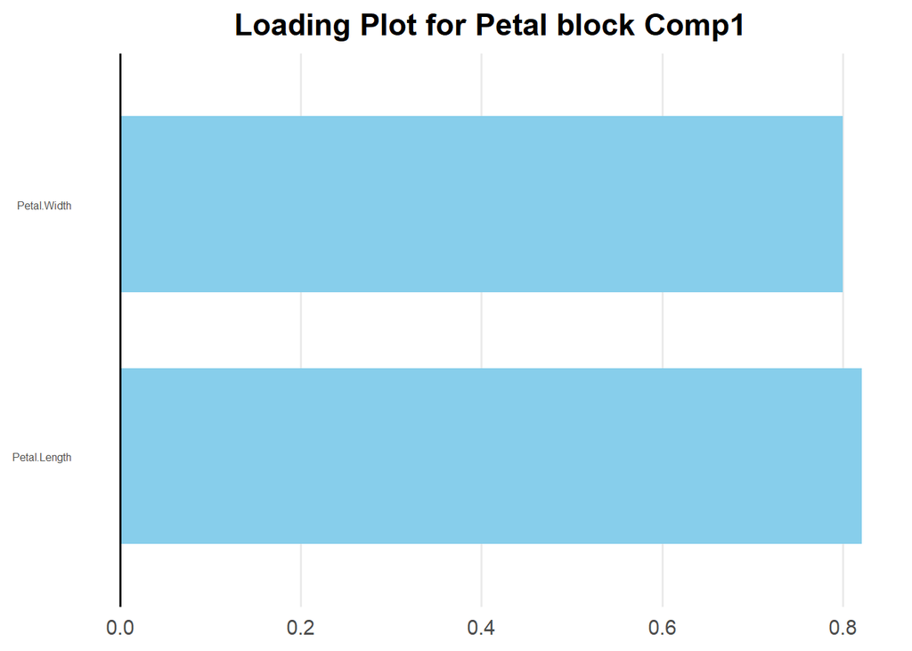

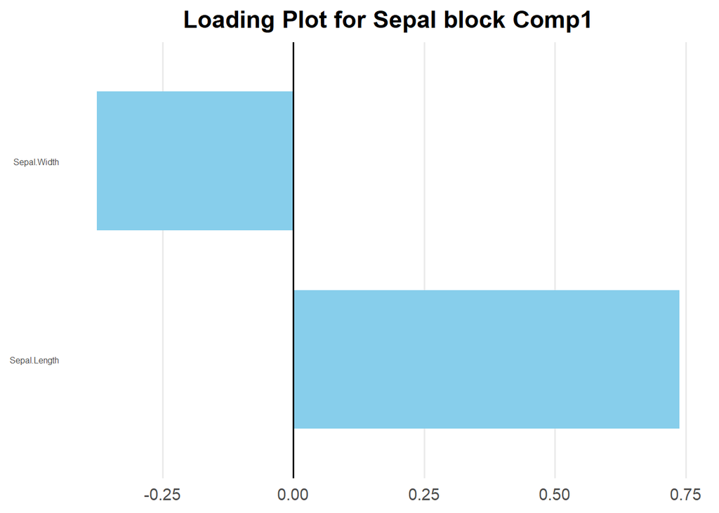

```r
# Block Loadings to see variable contributions within their respective blocks
plsPlot(mymbpls, type = 'loadingsX')
```

# PLSDA

## Running PLS Discriminant Analysis (PLS-DA)

When the response variable `Y` is categorical (e.g., treatment groups, phenotypes, or disease status), PLS-DA is the appropriate approach to model the relationship between the predictor matrix `X`and the response `Y`. In PLS-DA, latent components maximize class separation while capturing the covariance structure between `X` and `Y`.

In line with PCA, the `Preparing()` function can be called prior to fitting a PLS-DA model to handle essential matrix preprocessing. However, if the data is passed directly to the `plsda()` function, the model automatically applies conservative default parameters to ensure the data is appropriately preprocessed for PLS modelling.

In PLSandO, the `plsda()` function can easily be applied by:

```r
X = iris[, 1:4]
Y = iris[, 5, drop = FALSE]

# Fit PLS-DA model
myplsda = plsda(X, Y)
```

```
##
##  Running optimization:
##
##  Running optimization:
```

## Results exploration

Once the model has been fitted, similarly to `pls` case, some brief summary can be explored to evaluate the performance of the model has been fitted. The `pls()` output includes information about the explained variance, the predictive ability through evaluated via cross-validation, and some other metrics that allowed to determine the optimal number of components and which can be used to assess the reliability of the model’s predictions.

These results can easily be evaluated via:

```r
myplsda$summary
```

```
##   comp       R2X    cumR2X        R2Y    cumR2Y        Q2     cumQ2   F1score
## 1    1 0.7290283 0.7290283 0.47114301 0.4711430 0.4697378 0.4697378 0.5488230
## 2    2 0.2278912 0.9569196 0.08612593 0.5572689 0.0793160 0.5490538 0.8109259
##         MCC      Etot  BER
## 1 0.4910464 0.3333333 0.25
## 2 0.7263444 0.1866667 0.14
```

## Results visualization

The `plsdaPlot()` function serves as a versatile wrapper for visualizing PLS-DA results. It inherits most of the plotting capabilities found in `plsPlot()`, providing a consistent interface for model exploration.

In PLS-DA an additional plotting option `type='ncomp'` is introduced. While the package internally determines the optimal number of components based on the Balanced Error Rate (BER) to ensure robust performance across different class sizes, this visualization allows for a more comprehensive assessment. By using this plot, users can evaluate the choice of components through multiple lenses, including various model performance indicators and classification error metrics, to ensure the most stable model selection.

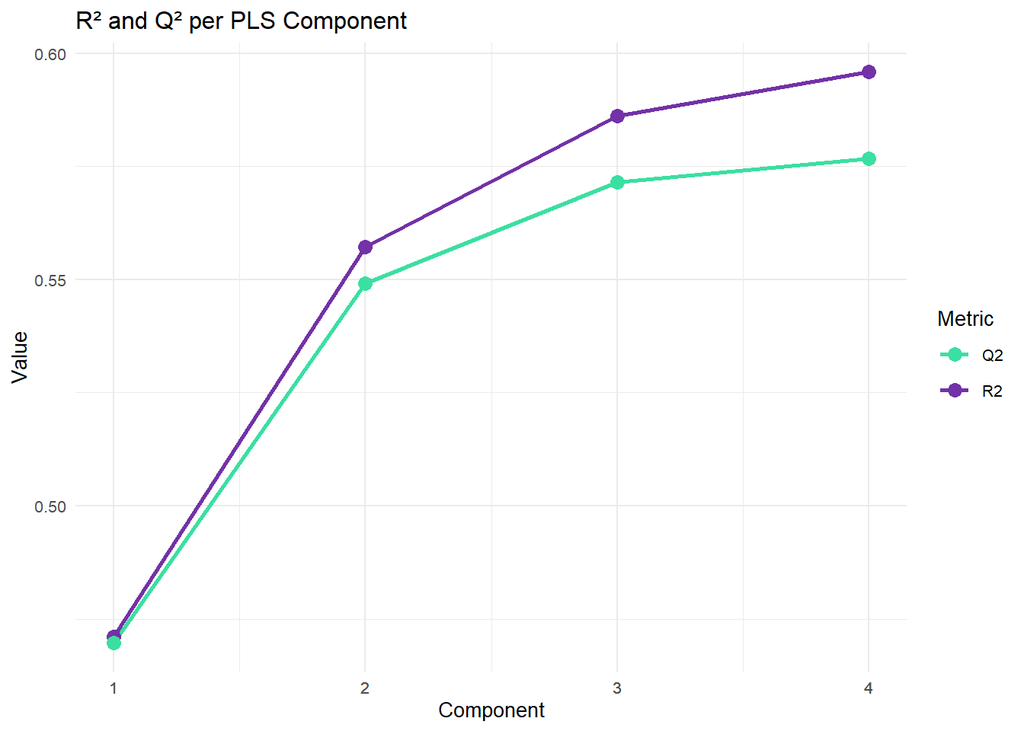

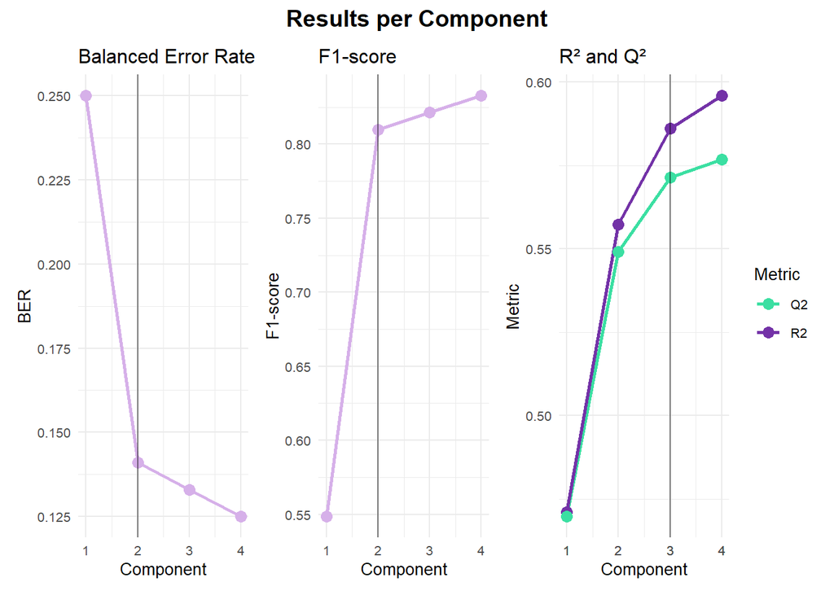

```r
# Performance and Model selection
plsdaPlot(myplsda, type = 'R2vsQ2')
plsdaPlot(myplsda, type = 'ncomp')
```

To better visualize group differentiation, `plsdaPlot()` automatically incorporates 95% confidence ellipses for the `Y` categories. These ellipses provide a statistical boundary that helps in assessing the separation and overlap between different classes in the score space.

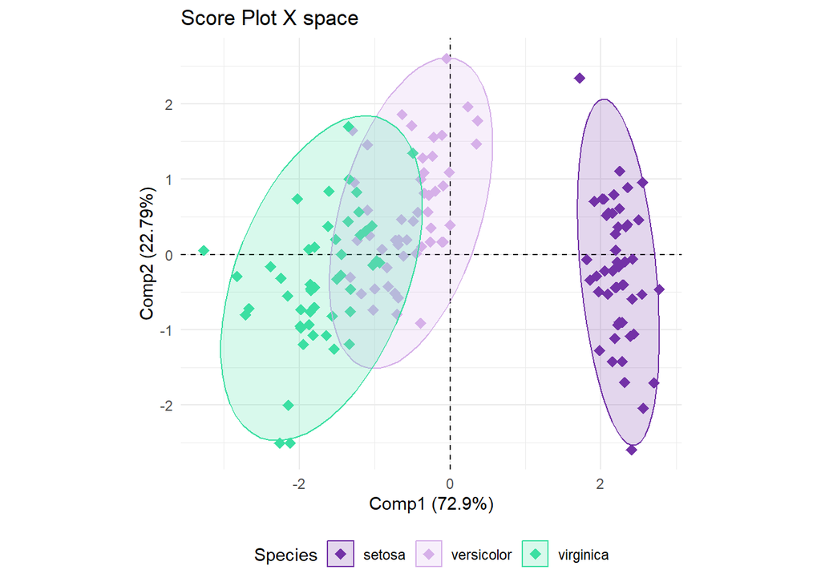

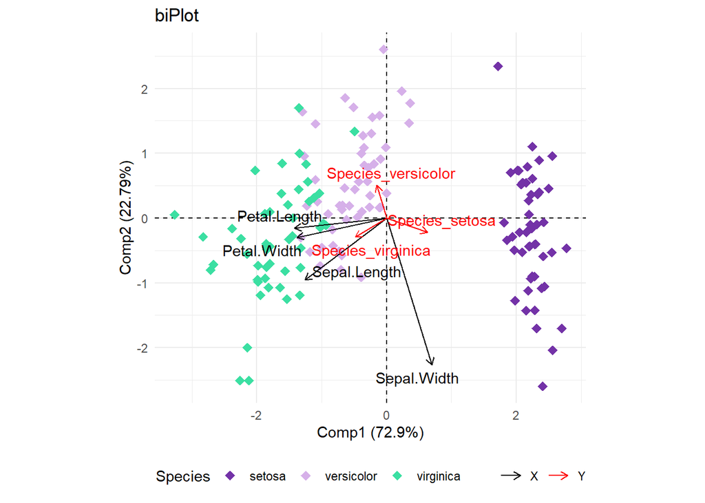

```r
# Space visualization
plsdaPlot(myplsda, type = 'scoresX')
plsdaPlot(myplsda, type = 'biplot')
```

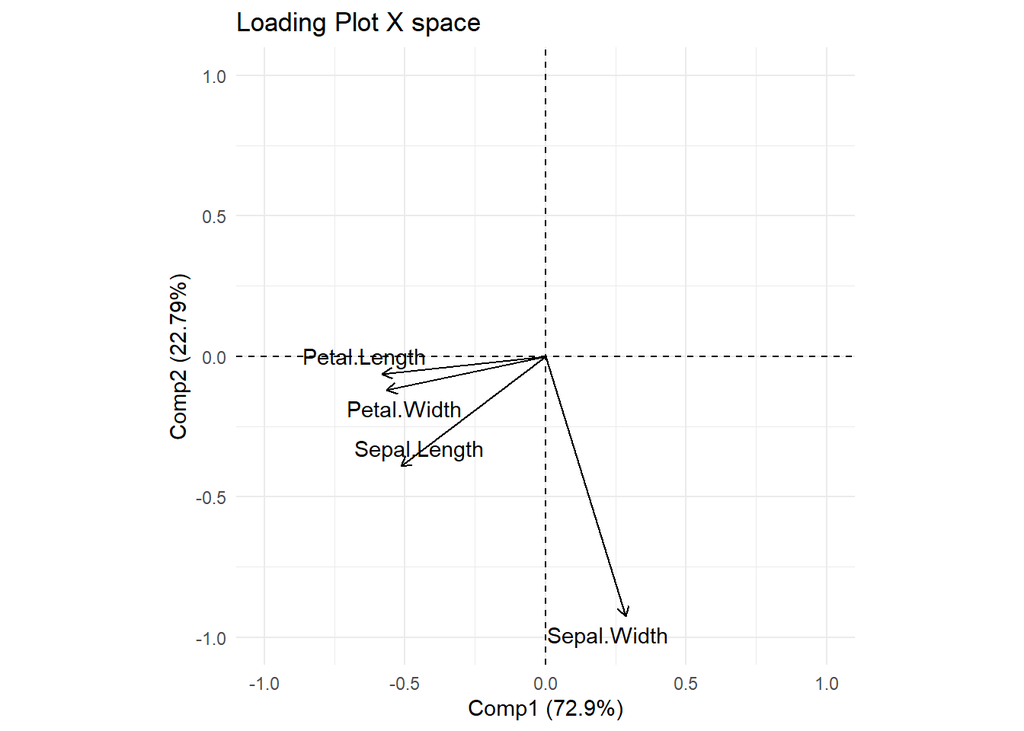

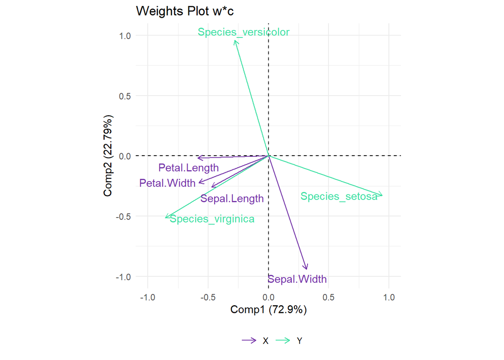

```r
# Variables contribution
plsdaPlot(myplsda, type = 'loadingsX')
plsdaPlot(myplsda, type = 'weights')
```

## Prediction

Prediction can easily be performed by `plsdaPredict()` function which outputs the categorical prediction of the model, the prediction of the pls model and the class membership probability.

```r
X_train = iris[1:125, 1:4]
Y_train = iris[1:125, 5, drop = FALSE]

X_test = iris[126:150, 1:4]

# Fit and Predict
myplsda_subset = plsda(X_train, Y_train)
```

```
##
##  Running optimization:
##
##  Running optimization:
```

```r
predictions = predict(myplsda_subset, new = X_test)
```

[figure not shown]

```r
head(predictions$yPred)
```

```
##     Species_setosa Species_versicolor Species_virginica
## 126    -0.10124251          0.4553659         0.6458766
## 127    -0.02243599          0.5991323         0.4233037
## 128     0.05562301          0.5096646         0.4347124
## 129    -0.17224264          0.6382813         0.5339613
## 130    -0.12148786          0.5345870         0.5869008
## 131    -0.30203248          0.6486576         0.6533749
```

```r
head(predictions$yProb)
```

```
##     Species_setosa Species_versicolor Species_virginica
## 126      0.2059454          0.3593223         0.4347323
## 127      0.2260658          0.4208997         0.3530345
## 128      0.2477936          0.3901915         0.3620149
## 129      0.1895601          0.4263371         0.3841028
## 130      0.2016971          0.3887133         0.4095896
## 131      0.1616234          0.4181996         0.4201770
```

```r
head(predictions$Class)
```

```
##      Species
## 1  virginica
## 2 versicolor
## 3 versicolor
## 4 versicolor
## 5  virginica
## 6  virginica
```

## Missing values

It is also robust against missing values.

```r
# Example with missing data and new observations
X_train = iris[1:125, 1:4]
Y_train = iris[1:125, 5, drop = FALSE]
X_train[1, 1] = NA # Introducing a missing value

X_test = iris[126:150, 1:4]
X_test[2, 1] = NA  # Missing value in new data

# Fit
myplsda_subset = plsda(X_train, Y_train)
```

```
##
##  Running optimization:
##
##  Running optimization:
```

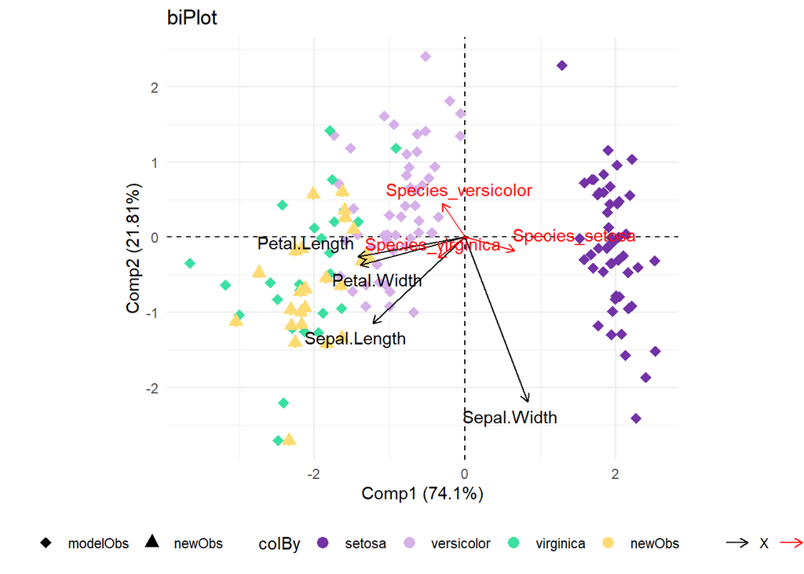

```r
# Visualize new observations in the existing space
plsdaPlot(myplsda_subset, type = 'biplot', newObs = X_test)
```

## Variable selection

Variable selection is also available for the same methodologies introduced in `plsVarSel()`.

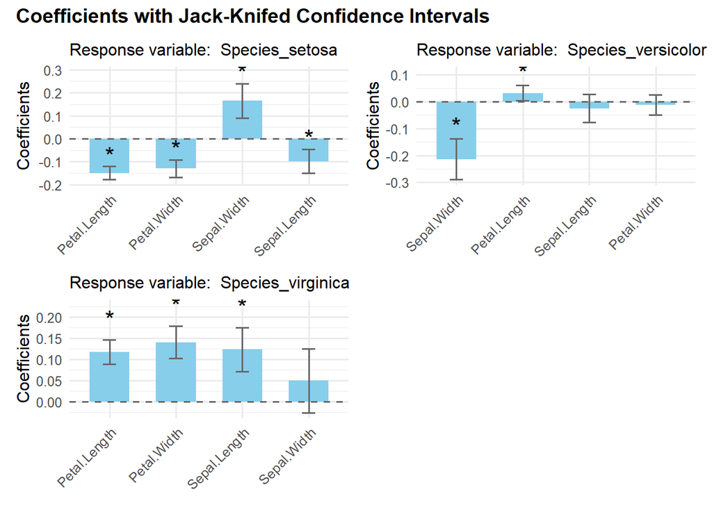

```
## $Species_setosa
##                    pValJK
## Petal.Length 5.547424e-19
## Petal.Width  3.741585e-10
## Sepal.Width  3.054032e-05
## Sepal.Length 2.828334e-04
##
## $Species_versicolor
##                    pValJK
## Sepal.Width  1.030273e-07
## Petal.Length 3.121238e-02
##
## $Species_virginica
##                    pValJK
## Petal.Length 2.132179e-13
## Petal.Width  1.455323e-11
## Sepal.Length 6.650180e-06
```

```r
# Variable selection via Jackknife (leave-one-out approach)
plsdaVarSel(myplsda, type = 'Jack')
```

## Outliers

Finally, some additional analysis can be performed for outlier detection.

```r
# Outlier detection and their contribution to the model
out = plsdaOutliers(myplsda)
plsdaOutlierContrib(myplsda, outliers = out)
```

```
## There are no severe outliers in the data or they were not computed.
## There are 2 moderate outliers in the data.
```

```
## $contribT2
## NULL
##
## $contribRSS
##      Sepal.Length Sepal.Width Petal.Length Petal.Width
## r107    -68.10241  0.99272718     4.321395    26.58347
## r115    -50.20739  0.09103985    -1.059930    48.64164
```

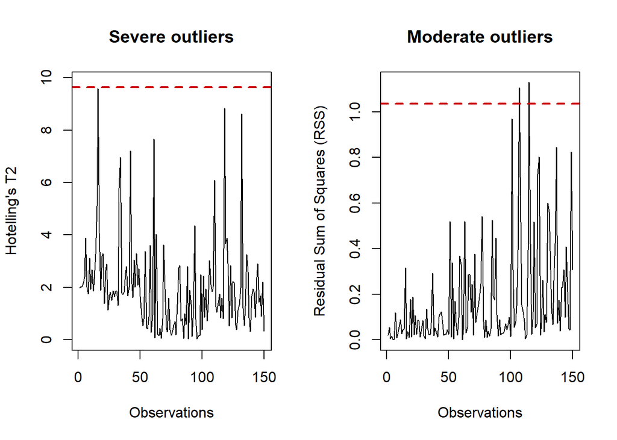

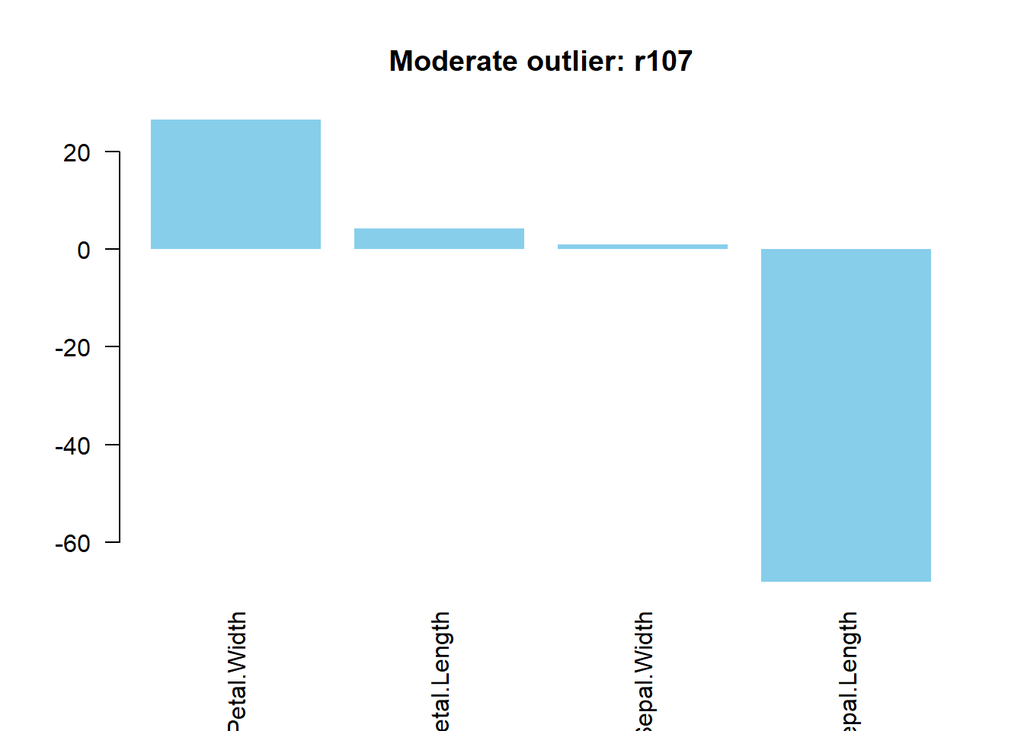

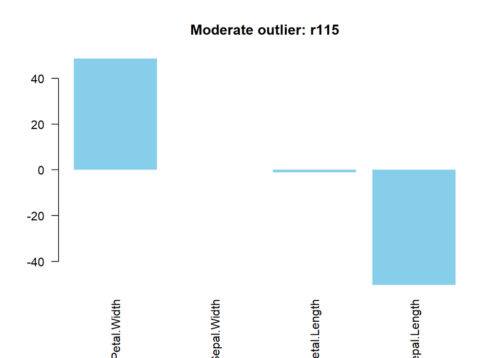

## Running Multi-block PLS Discriminant Analysis (MBPLSDA)

Similarly to MBPLS, the MBPLS-DA algorithm is used when predictors are structured in blocks but the goal is classification.

To run an MBPLS-DA, provide the `X` data as a list and set `algo = 'mbplsda'`.

```r
# Organize data into blocks
X= list('Petal' = iris[, c(3, 4)], 'Sepal' = iris[, c(1, 2)])
Y = iris[, 5, drop = FALSE]

# Fit Multi-block PLS-DA
mymbplsda = plsda(X, Y, algo = 'mbplsda')
```

```
##
##  Running optimization:
##
##  Running optimization:
```

All previously presented plots are also allowed in MBPLSDA, but results are show at block and super level. An example will be showed with the visualization of the Scores and loadings.

```r
# Score plot with ellipses for classes
plsdaPlot(mymbplsda, type = 'scoresX')
```

[figure not shown]

[figure not shown]

[figure not shown]

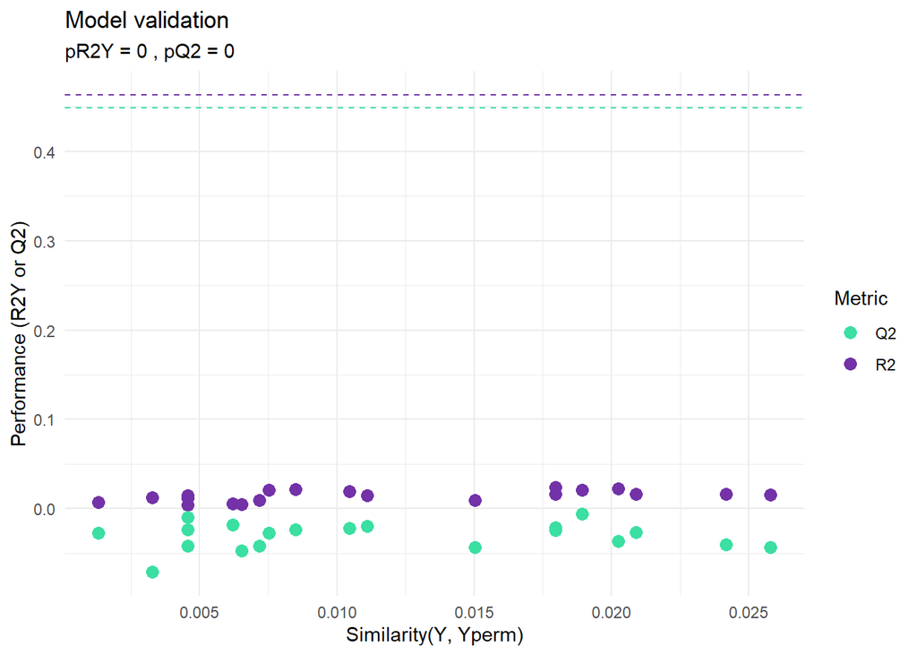

```r
# Evaluate linearity and overfitting
plsdaPlot(mymbplsda, type = 'overfitting')
```

Predicting with multi-block data requires the new input to maintain the same list structure as the training blocks.

```r
# Define training and test sets for blocks
X_train = list('Petal' = iris[1:125, c(3, 4)], 'Sepal' = iris[1:125, c(1, 2)])
X_test = list('Petal' = iris[126:150, c(3, 4)], 'Sepal' = iris[126:150, c(1, 2)])
Y_train = iris[1:125, 5, drop = FALSE]

# Model and Predict
mymbplsda2 = plsda(X_train, Y_train, algo = 'mbplsda', ncomp = 2)
```

```
##
##  Running optimization:
##
##  Running optimization:
```

```r
mb_preds = predict(mymbplsda2, new = X_test)
```

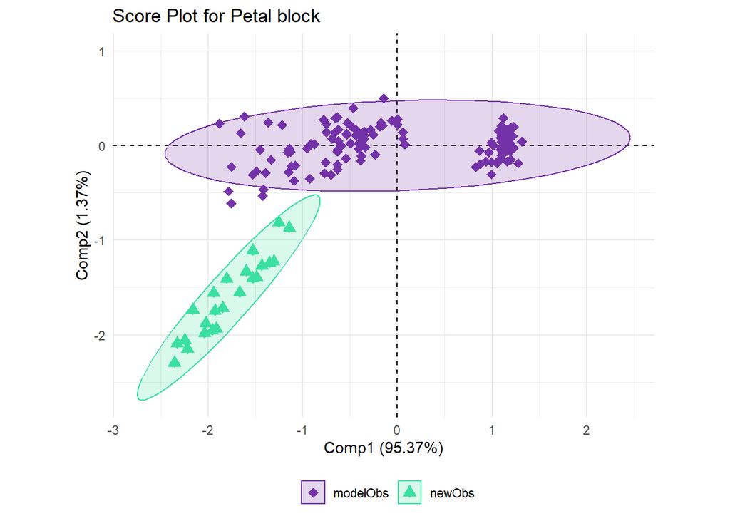

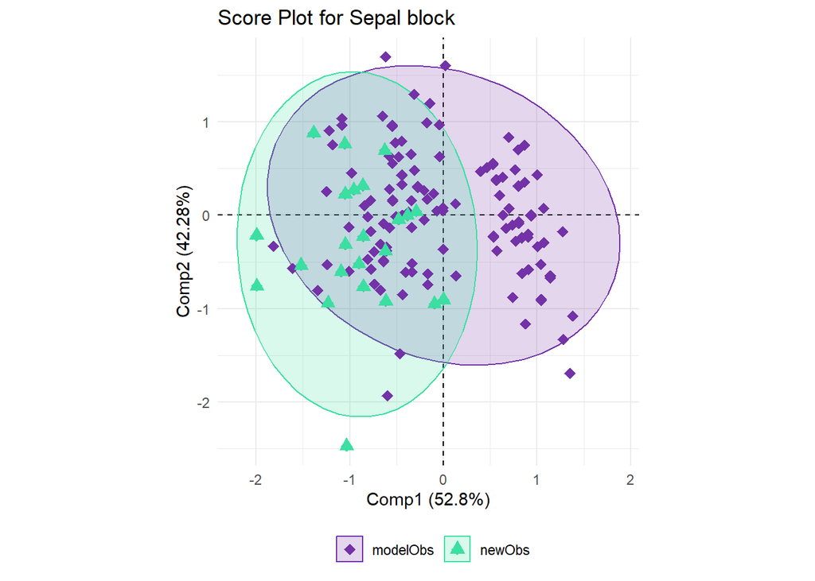

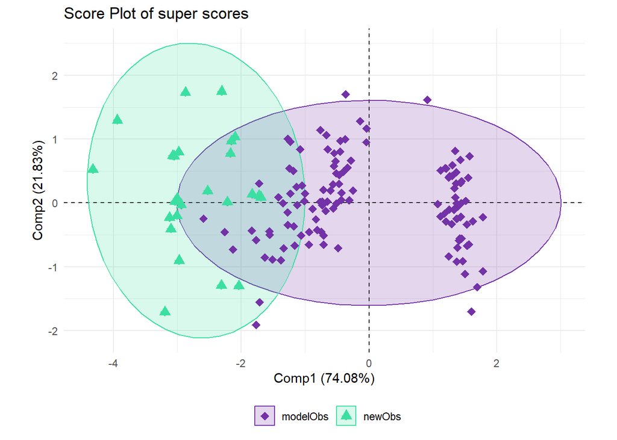

# Multilevel Analysis

The `multilevel()` function is specifically designed for study designs with repeated measures or crossover structures. It accounts for variability across different levels of the data (for example, between subjects or clusters) so that these sources of variation are properly separated from the effects of interest.

The multilevel approach handles this by decomposing the data matrix into three separate parts before applying multivariate models: - Offset (`X_m`): Captures the mean of all variables in `X`. - Within-subject variation (`X_w`): Captures the changes occurring within the same individual across different conditions. This is typically the variation of interest. - Between-subject variation (`X_b`): Captures the intrinsic differences between individuals.

To demonstrate the functionality of the `multilevel()` function, we will use a repeated-measures dataset from the mixOmics package.

## Running multilevel PCA

[output not shown]

```
## X.115 X.147 X.163 X.179  X.19   X.3
##     8     7     9    11    10     1
```

Once the data is prepared the multilevel will be applied to account for the study design when exploring the data.

```r
# Fit a Multilevel PCA
multipca = multilevel(X, design = design)
names(multipca)
```

```
## [1] "Within"  "Between" "Xm"      "Xw"      "Xb"      "input"
```

### Results Visualization

The `multilevelPlot()` function automatically accounts for the structure of multilevel objects, and all options available in `pcaPlot()` can also be used here. For exploratory analysis, both within- and between-subject variations can be visualized jointly. In addition, the `$Within` and `$Between` objects of a multilevel object are themselves PCA objects, meaning that all standard PCA functionalities can be applied to them separately. Some examples are shown below.

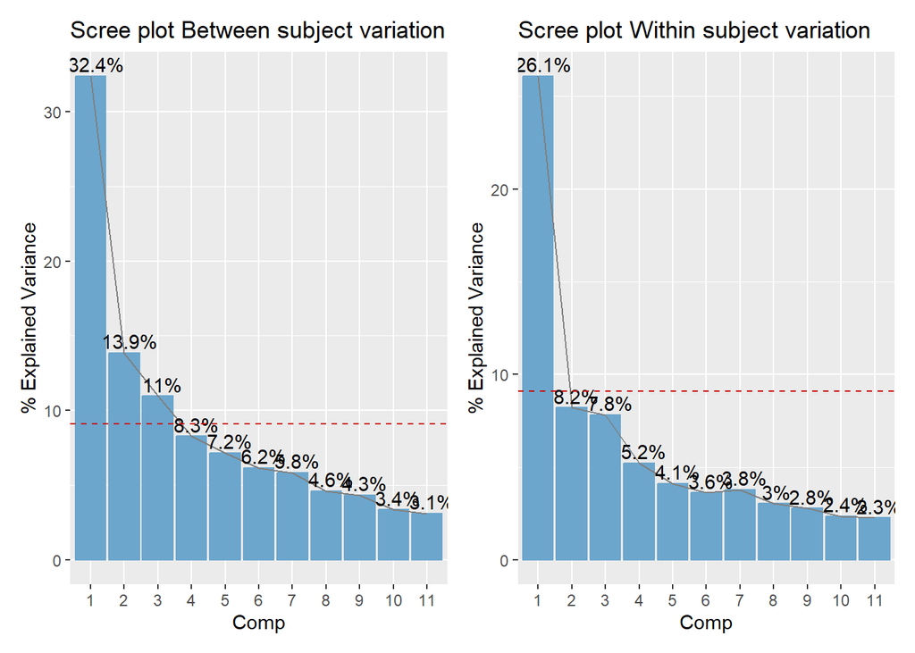

```r
#Create the scree plot
multilevelPlot(multipca, type ='scree' )
```

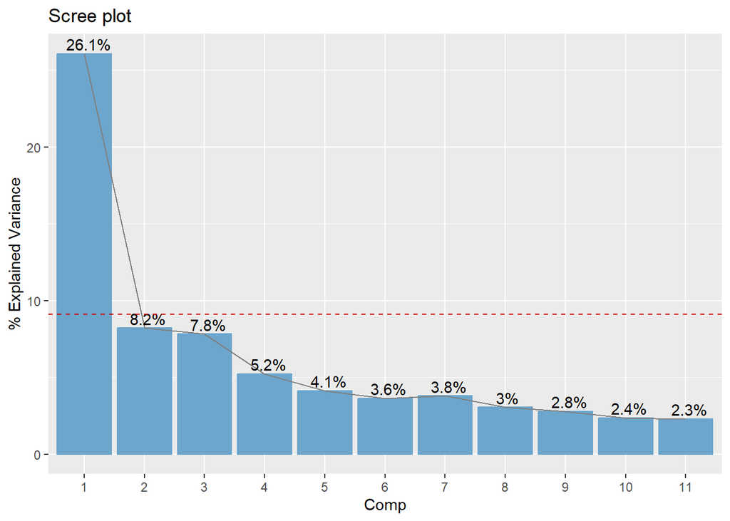

```r
#Obtain the same plot for the Within part using pcaPlot
pcaPlot(multipca$Within, type ='scree')
```

To have a look at the scores, we can simply run:

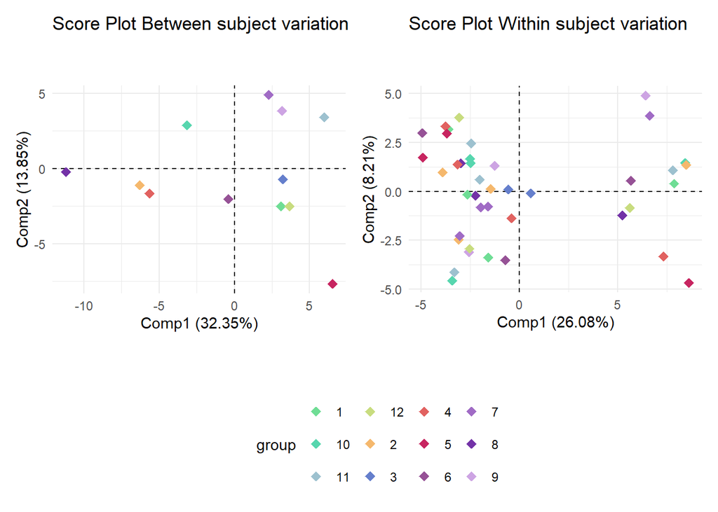

```r
#Explore the score plot
multilevelPlot(multipca, type='scores')
```

## Running multilevel PLSDA

The dataset also contains class information that can be used for supervised analysis. We will use it to illustrate how to run a PLS-DA model with repeated measurements.

```r
# Loading mixOmics data and preparing the data as needed for PLSandO
Y = as.data.frame(vac18$stimulation)
rownames(Y) = rownames(X)
```

Once the data are prepared, the multilevel approach can be applied to account for the study design during model fitting and exploration.

```r
# Fit a Multilevel PLSDA
multiplsda = multilevel(X, Y, design = design, method = 'plsda')
```

```
##
##  Running optimization:
```

[output not shown]

```r
names(multiplsda)
```

```
## [1] "model" "Xm"    "Xw"    "Xb"    "input"
```

### Results Visualization

The `multilevelPlot()` function automatically handles the structure of multilevel objects, regardless of the method used. When `method = 'plsda'`, it focuses on visualizing within-subject variation.

First, the optimal number of components should be determined. For this purpose, we examine the plot with `type = 'ncomp'`.

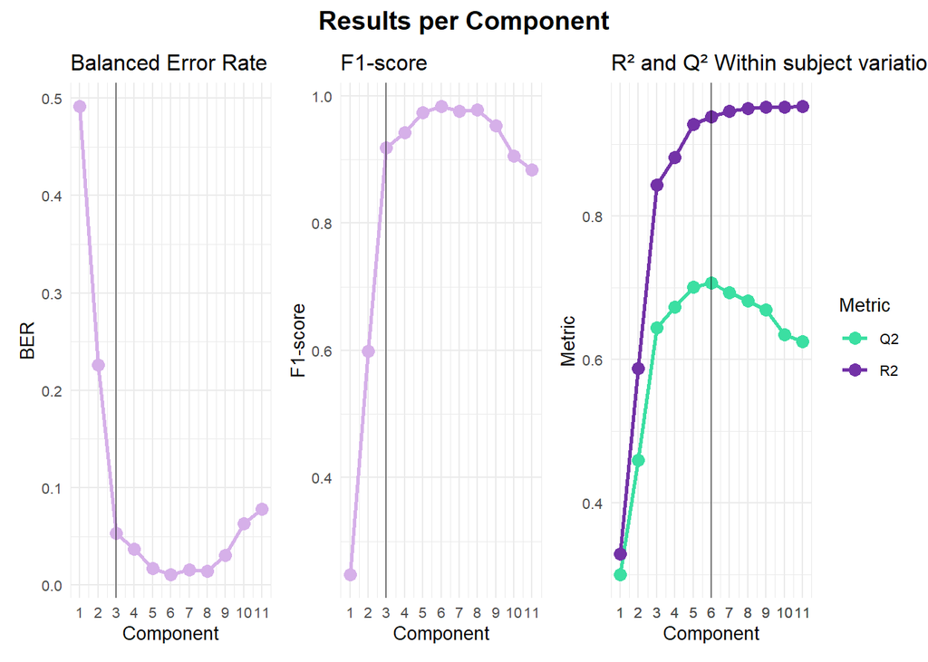

```r
#Create the scree plot based on different metrics
multilevelPlot(multiplsda, type ='ncomp' )
```

Most classification error–based metrics indicate that 3 components are optimal. The model is therefore re-fitted using this number of components.

```r
multiplsda = multilevel(X, Y, design = design, method = 'plsda', ncomp = 3)
```

```
##
##  Running optimization:
```

[output not shown]

Finally, the results can be explored.

```r
#Explore the model results
multiplsda$model$summary
```

```
##   comp        R2X    cumR2X       R2Y    cumR2Y        Q2     cumQ2   F1score
## 1    1 0.26057575 0.2605757 0.3292454 0.3292454 0.3002058 0.3002058 0.3732765
## 2    2 0.07398438 0.3345601 0.2585199 0.5877653 0.1599393 0.4601451 0.7092739
## 3    3 0.04837020 0.3829303 0.2553636 0.8431289 0.1839713 0.6441164 0.9999994
##         MCC      Etot       BER
## 1 0.3296504 0.4761905 0.3306449
## 2 0.7091697 0.2142857 0.1484122
## 3 1.0000000 0.0000000 0.0000000
```

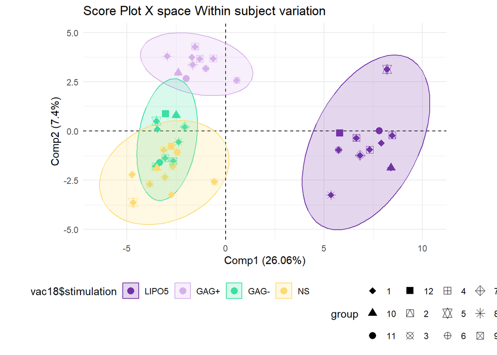

```r
#Create the score plot
multilevelPlot(multiplsda, type='scoresX')
```

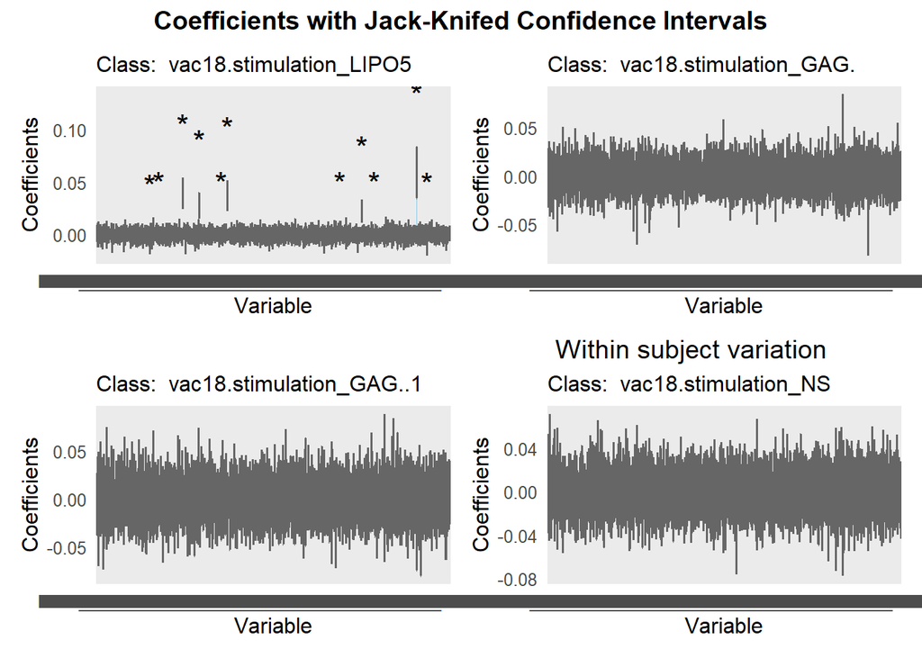

```r
#Look at the model coefficients
multilevelPlot(multiplsda, type = 'coef')
```

### Prediction

Prediction in a multilevel context requires both the new data (`new`) and the information specifying the subject to which each sample belongs (`design`). Prediction can easily be performed by `multilevelPredict()` function which outputs the categorical prediction of the model and the prediction of the pls model.

In the following example, a subset of samples is held from the training data and used to evaluate the prediction procedure.

```r
#Prepare the training data
X = vac18$genes[-c(4,17,26,37,7,28,39),]
Y = as.data.frame(vac18$stimulation[-c(4,17,26,37,7,28,39)])
rownames(Y) = rownames(X)

design = vac18$sample[-c(4,17,26,37,7,28,39)]
names(design) = rownames(Y)

#Fit the model
mymultiplsda = multilevel(X, Y, design, method = 'plsda')
```

```
##
##  Running optimization:
```

[output not shown]

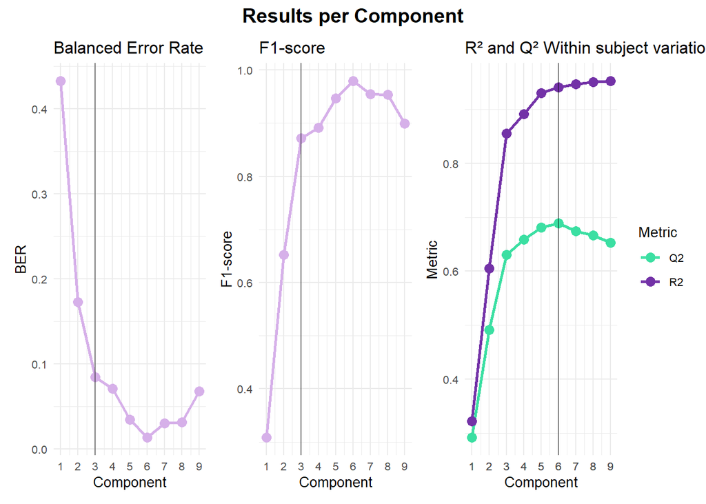

```r
#Select the optimal number of components
multilevelPlot(mymultiplsda, type ='ncomp')
```

```r
#Fit the model with the optimal number of components
mymultiplsda = multilevel(X, Y, design, method = 'plsda', ncomp = 3)
```

```
##
##  Running optimization:
```

[output not shown]

```r
#Test data preparation
Xtest = vac18$genes[c(4,17,26,37,7,28,39),]
designTest = vac18$sample[c(4,17,26,37,7,28,39)]
names(designTest) = rownames(Xtest)

#Test data prediction
myprediction = predict(mymultiplsda, new = Xtest, design = designTest)
```

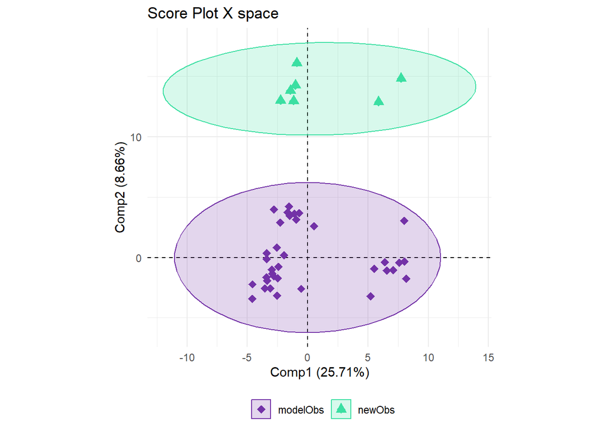

```r
head(myprediction$yPred)
```

```
##       vac18.stimulation..c.4..17..26..37..7..28..39.._LIPO5
## X.179                                           0.931174885
## X.183                                           0.030975481
## X.187                                          -0.003137053
## X.191                                           0.069558117
## X.35                                            0.747347258
## X.43                                           -0.005533104
##       vac18.stimulation..c.4..17..26..37..7..28..39.._GAG.
## X.179                                            0.1184689
## X.183                                            0.5459488
## X.187                                            0.0436827
## X.191                                            0.3204710
## X.35                                             0.0427759
## X.43                                             0.3400223
##       vac18.stimulation..c.4..17..26..37..7..28..39.._GAG..1
## X.179                                             0.13469929
## X.183                                             0.23010635
## X.187                                             0.46491566
## X.191                                             0.08456442
## X.35                                              0.27179208
## X.43                                              0.49023542
##       vac18.stimulation..c.4..17..26..37..7..28..39.._NS
## X.179                                        -0.18434303
## X.183                                         0.19296935
## X.187                                         0.49453869
## X.191                                         0.52540642
## X.35                                         -0.06191523
## X.43                                          0.17527536
```

```r
head(myprediction$yProb)
```

```
##       vac18.stimulation..c.4..17..26..37..7..28..39.._LIPO5
## X.179                                             0.4499809
## X.183                                             0.1972469
## X.187                                             0.1890463
## X.191                                             0.2050093
## X.35                                              0.3904654
## X.43                                              0.1903776
##       vac18.stimulation..c.4..17..26..37..7..28..39.._GAG.
## X.179                                            0.1996367
## X.183                                            0.3301112
## X.187                                            0.1981079
## X.191                                            0.2634775
## X.35                                             0.1930150
## X.43                                             0.2689606
##       vac18.stimulation..c.4..17..26..37..7..28..39.._GAG..1
## X.179                                              0.2029033
## X.183                                              0.2407086
## X.187                                              0.3018846
## X.191                                              0.2081089
## X.35                                               0.2426898
## X.43                                               0.3125542
##       vac18.stimulation..c.4..17..26..37..7..28..39.._NS
## X.179                                          0.1474792
## X.183                                          0.2319333
## X.187                                          0.3109611
## X.191                                          0.3234044
## X.35                                           0.1738298
## X.43                                           0.2281077
```

```r
head(myprediction$Class)
```

```
##   vac18.stimulation..c.4..17..26..37..7..28..39..
## 1                                           LIPO5
## 2                                            GAG.
## 3                                              NS
## 4                                              NS
## 5                                           LIPO5
## 6                                          GAG..1
```

## Running multilevel PLS

The PLS model is run in a similar way. In this case, we do not include a full example with results, but the following code illustrates how the model can be fitted.

```r
multipls = multilevel(X, Y, design = design, method = 'pls')
```

# Parallelization

The whole package supports parallel computation for model fitting, which can be easily enabled by setting `parallel = TRUE`. This feature is available across all implemented methods, including PCA, MBPCA, PLS, MBPLS, PLSDA, MBPLSDA, and multilevel approaches. Parallelization is particularly beneficial when working with high-dimensional datasets, where computational demands can be substantial.

An example with prior dataset is provided below to illustrate its use.

```r
multiplsda = multilevel(X, Y, design = design, method = 'plsda', parallel=TRUE)
```

```
##
##  Running optimization:
##
##  Running optimization:
```